# 05_Data_Exploration

- The IRIS dataset:
  - Load the dataset
  - Explore the dataset: Descriptive statistics
  - Explore the dataset: Visualization
- The BREAST-CANCER dataset:
  - Load the dataset
  - Explore the dataset: Descriptive statistics
  - Explore the dataset: Visualization

```python
import os
import pandas as pd
```

# Data Exploration (numerical data): The IRIS dataset

This is perhaps the best known database to be found in the pattern recognition literature.

- The data set contains 3 classes of 50 instances each, where each class refers to a type of iris plant.
- There are four numeric attributes and the class attribute:
  1. sepal length in cm
  2. sepal width in cm
  3. petal length in cm
  4. petal width in cm
  5. class: {Iris Setosa, Iris Versicolour, Iris Virginica}

[figure not shown]

## Load the dataset

Common pitfalls in `pd.read_csv`:

- what is the "sep" character
- is there any header?
- is there any index column?
- how are missing/unknown values denoted?

```python
iris_df = pd.read_csv(os.path.join('dataset', 'iris.csv'))
```

## Explore the dataset: descriptive statistics

```python
iris_df
```

|  | sepallength | sepalwidth | petallength | petalwidth | class |
| --- | --- | --- | --- | --- | --- |
| 0 | 5.1 | 3.5 | 1.4 | 0.2 | 1 |
| 1 | 4.9 | 3.0 | 1.4 | 0.2 | 1 |
| 2 | 4.7 | 3.2 | 1.3 | 0.2 | 1 |
| 3 | 4.6 | 3.1 | 1.5 | 0.2 | 1 |
| 4 | 5.0 | 3.6 | 1.4 | 0.2 | 1 |
| ... | ... | ... | ... | ... | ... |
| 145 | 6.7 | 3.0 | 5.2 | 2.3 | 3 |
| 146 | 6.3 | 2.5 | 5.0 | 1.9 | 3 |
| 147 | 6.5 | 3.0 | 5.2 | 2.0 | 3 |
| 148 | 6.2 | 3.4 | 5.4 | 2.3 | 3 |
| 149 | 5.9 | 3.0 | 5.1 | 1.8 | 3 |

150 rows × 5 columns

```python
iris_df.shape
```

```
(150, 5)
```

```python
pd.set_option('display.max_rows', 150)
iris_df
```

|  | sepallength | sepalwidth | petallength | petalwidth | class |
| --- | --- | --- | --- | --- | --- |
| 0 | 5.1 | 3.5 | 1.4 | 0.2 | 1 |
| 1 | 4.9 | 3.0 | 1.4 | 0.2 | 1 |
| 2 | 4.7 | 3.2 | 1.3 | 0.2 | 1 |
| 3 | 4.6 | 3.1 | 1.5 | 0.2 | 1 |
| 4 | 5.0 | 3.6 | 1.4 | 0.2 | 1 |
| 5 | 5.4 | 3.9 | 1.7 | 0.4 | 1 |
| 6 | 4.6 | 3.4 | 1.4 | 0.3 | 1 |
| 7 | 5.0 | 3.4 | 1.5 | 0.2 | 1 |
| 8 | 4.4 | 2.9 | 1.4 | 0.2 | 1 |
| 9 | 4.9 | 3.1 | 1.5 | 0.1 | 1 |
| 10 | 5.4 | 3.7 | 1.5 | 0.2 | 1 |
| 11 | 4.8 | 3.4 | 1.6 | 0.2 | 1 |
| 12 | 4.8 | 3.0 | 1.4 | 0.1 | 1 |
| 13 | 4.3 | 3.0 | 1.1 | 0.1 | 1 |
| 14 | 5.8 | 4.0 | 1.2 | 0.2 | 1 |
| 15 | 5.7 | 4.4 | 1.5 | 0.4 | 1 |
| 16 | 5.4 | 3.9 | 1.3 | 0.4 | 1 |
| 17 | 5.1 | 3.5 | 1.4 | 0.3 | 1 |
| 18 | 5.7 | 3.8 | 1.7 | 0.3 | 1 |
| 19 | 5.1 | 3.8 | 1.5 | 0.3 | 1 |
| 20 | 5.4 | 3.4 | 1.7 | 0.2 | 1 |
| 21 | 5.1 | 3.7 | 1.5 | 0.4 | 1 |
| 22 | 4.6 | 3.6 | 1.0 | 0.2 | 1 |
| 23 | 5.1 | 3.3 | 1.7 | 0.5 | 1 |
| 24 | 4.8 | 3.4 | 1.9 | 0.2 | 1 |
| 25 | 5.0 | 3.0 | 1.6 | 0.2 | 1 |
| 26 | 5.0 | 3.4 | 1.6 | 0.4 | 1 |
| 27 | 5.2 | 3.5 | 1.5 | 0.2 | 1 |
| 28 | 5.2 | 3.4 | 1.4 | 0.2 | 1 |
| 29 | 4.7 | 3.2 | 1.6 | 0.2 | 1 |

[output cut: 120 more lines]

```python
iris_df.head(10)
```

|  | sepallength | sepalwidth | petallength | petalwidth | class |
| --- | --- | --- | --- | --- | --- |
| 0 | 5.1 | 3.5 | 1.4 | 0.2 | 1 |
| 1 | 4.9 | 3.0 | 1.4 | 0.2 | 1 |
| 2 | 4.7 | 3.2 | 1.3 | 0.2 | 1 |
| 3 | 4.6 | 3.1 | 1.5 | 0.2 | 1 |
| 4 | 5.0 | 3.6 | 1.4 | 0.2 | 1 |
| 5 | 5.4 | 3.9 | 1.7 | 0.4 | 1 |
| 6 | 4.6 | 3.4 | 1.4 | 0.3 | 1 |
| 7 | 5.0 | 3.4 | 1.5 | 0.2 | 1 |
| 8 | 4.4 | 2.9 | 1.4 | 0.2 | 1 |
| 9 | 4.9 | 3.1 | 1.5 | 0.1 | 1 |

```python
iris_df.head(10).T
```

|  | 0 | 1 | 2 | 3 | 4 | 5 | 6 | 7 | 8 | 9 |
| --- | --- | --- | --- | --- | --- | --- | --- | --- | --- | --- |
| sepallength | 5.1 | 4.9 | 4.7 | 4.6 | 5.0 | 5.4 | 4.6 | 5.0 | 4.4 | 4.9 |
| sepalwidth | 3.5 | 3.0 | 3.2 | 3.1 | 3.6 | 3.9 | 3.4 | 3.4 | 2.9 | 3.1 |
| petallength | 1.4 | 1.4 | 1.3 | 1.5 | 1.4 | 1.7 | 1.4 | 1.5 | 1.4 | 1.5 |
| petalwidth | 0.2 | 0.2 | 0.2 | 0.2 | 0.2 | 0.4 | 0.3 | 0.2 | 0.2 | 0.1 |
| class | 1.0 | 1.0 | 1.0 | 1.0 | 1.0 | 1.0 | 1.0 | 1.0 | 1.0 | 1.0 |

Check if there is any missing value

```python
iris_df.isna().sum()
```

```
sepallength    0
sepalwidth     0
petallength    0
petalwidth     0
class          0
dtype: int64
```

```python
iris_df.describe()
```

|  | sepallength | sepalwidth | petallength | petalwidth | class |
| --- | --- | --- | --- | --- | --- |
| count | 150.000000 | 150.000000 | 150.000000 | 150.000000 | 150.000000 |
| mean | 5.843333 | 3.054000 | 3.758667 | 1.198667 | 2.000000 |
| std | 0.828066 | 0.433594 | 1.764420 | 0.763161 | 0.819232 |
| min | 4.300000 | 2.000000 | 1.000000 | 0.100000 | 1.000000 |
| 25% | 5.100000 | 2.800000 | 1.600000 | 0.300000 | 1.000000 |
| 50% | 5.800000 | 3.000000 | 4.350000 | 1.300000 | 2.000000 |
| 75% | 6.400000 | 3.300000 | 5.100000 | 1.800000 | 3.000000 |
| max | 7.900000 | 4.400000 | 6.900000 | 2.500000 | 3.000000 |

```python
iris_df.drop('class', axis = 1).describe()
```

|  | sepallength | sepalwidth | petallength | petalwidth |
| --- | --- | --- | --- | --- |
| count | 150.000000 | 150.000000 | 150.000000 | 150.000000 |
| mean | 5.843333 | 3.054000 | 3.758667 | 1.198667 |
| std | 0.828066 | 0.433594 | 1.764420 | 0.763161 |
| min | 4.300000 | 2.000000 | 1.000000 | 0.100000 |
| 25% | 5.100000 | 2.800000 | 1.600000 | 0.300000 |
| 50% | 5.800000 | 3.000000 | 4.350000 | 1.300000 |
| 75% | 6.400000 | 3.300000 | 5.100000 | 1.800000 |
| max | 7.900000 | 4.400000 | 6.900000 | 2.500000 |

```python
iris_df.info()
```

```
<class 'pandas.core.frame.DataFrame'>
RangeIndex: 150 entries, 0 to 149
Data columns (total 5 columns):
 #   Column       Non-Null Count  Dtype
---  ------       --------------  -----
 0   sepallength  150 non-null    float64
 1   sepalwidth   150 non-null    float64
 2   petallength  150 non-null    float64
 3   petalwidth   150 non-null    float64
 4   class        150 non-null    int64
dtypes: float64(4), int64(1)
memory usage: 6.0 KB
```

```python
iris_df['class'].value_counts()
```

```
class
1    50
2    50
3    50
Name: count, dtype: int64
```

## Explore the dataset: Visualization

```python
from matplotlib import pyplot as plt
```

### Histogram and boxplots with matplotlib

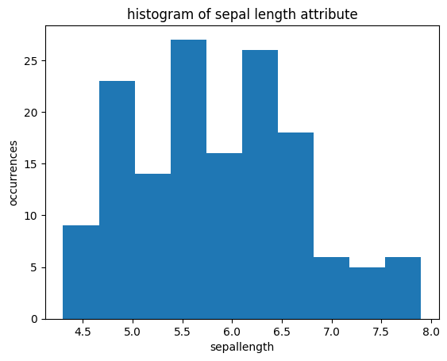

```python
plt.figure()
plt.hist(iris_df['sepallength'])
plt.ylabel('occurrences')
plt.xlabel('sepallength')
plt.title(f'histogram of sepal length attribute')
```

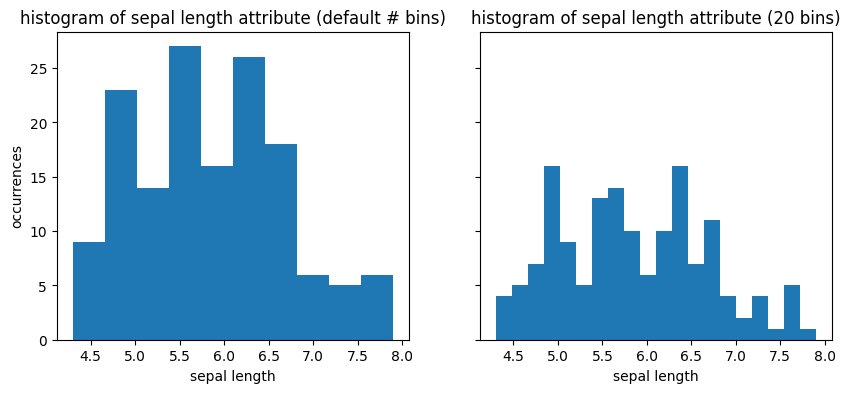

```python
f, axes = plt.subplots(1, 2, sharey = True, figsize = (10, 4))
axes[0].hist(iris_df['sepallength'])
axes[0].set_ylabel('occurrences')
axes[0].set_xlabel('sepal length')
axes[0].set_title(f'histogram of sepal length attribute (default # bins)')
axes[1].hist(iris_df['sepallength'], bins = 20)
axes[1].set_xlabel('sepal length')
axes[1].set_title(f'histogram of sepal length attribute (20 bins)')
plt.show()
```

### Histogram and boxplots with pandas

[Check the user guide](https://pandas.pydata.org/pandas-docs/stable/user_guide/visualization.html)

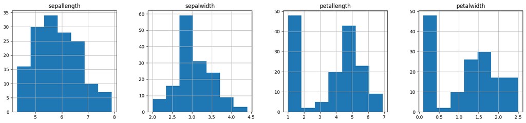

```python
iris_df.drop('class', axis = 1).hist(bins = 7,
                                     layout = (1, 4),
                                     figsize = (20, 4))
plt.show()
```

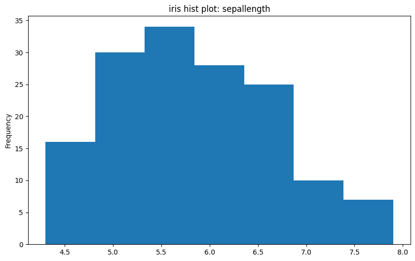

```python
iris_df['sepallength'].plot(kind = 'hist',
                            bins = 7,
                            figsize = (10, 6),
                            title = 'iris hist plot: sepallength')
plt.show()
```

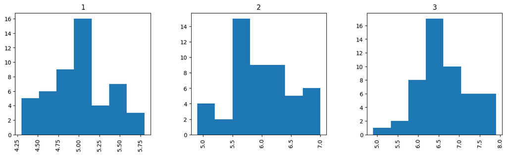

```python
iris_df.hist(column = 'sepallength',
             by='class',
             bins = 7,
             figsize=(15, 4),
             layout = (1, 3))
plt.show()
```

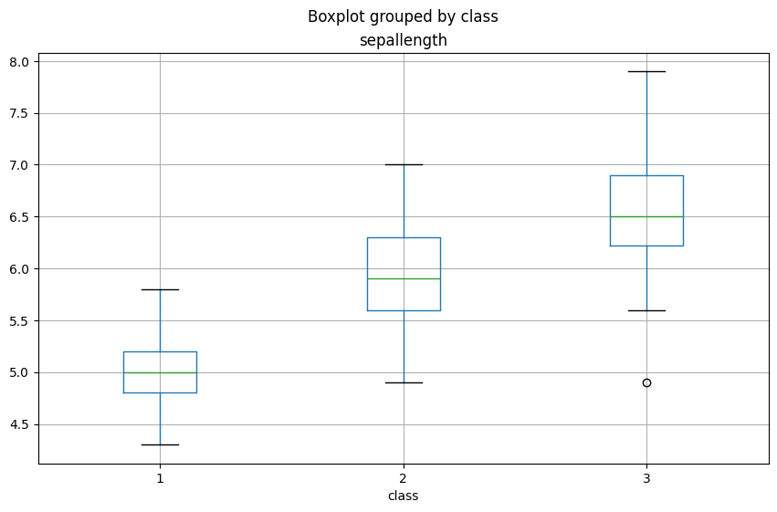

```python
iris_df.boxplot(column = 'sepallength',
                by = 'class',
                figsize = (10, 6))
plt.show()
```

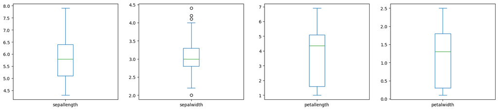

```python
iris_df.drop('class', axis = 1).plot(kind ='box',
                                    subplots = True,
                                    figsize = (20, 4),
                                    layout = (1, 4),
                                    sharey = False)
plt.show()
```

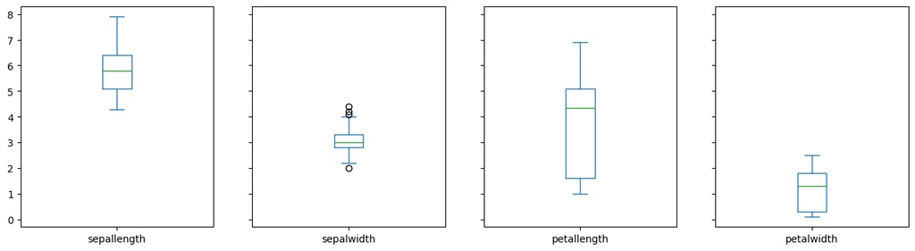

```python
iris_df.drop('class', axis = 1).plot(kind = 'box',
                                    subplots = True,
                                    figsize = (16, 4),
                                    layout = (1, 4),
                                    sharey = True)
plt.show()
```

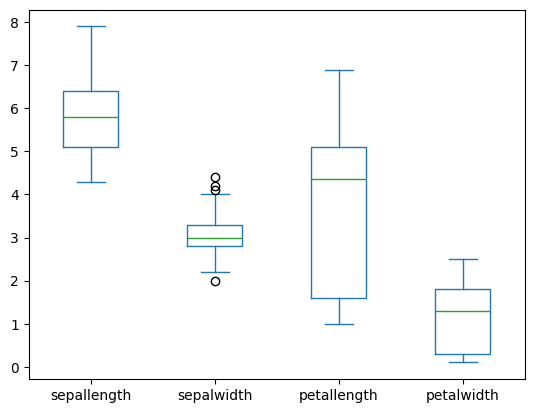

```python
iris_df.drop('class', axis = 1).plot(kind = 'box')
plt.show()
```

### Scatter plot with matplotlib

```python
dict_names = {1: 'Iris-setosa', 2: 'Iris-versicolor', 3: 'Iris-virginica'}
dict_names.values()
```

```
dict_values(['Iris-setosa', 'Iris-versicolor', 'Iris-virginica'])
```

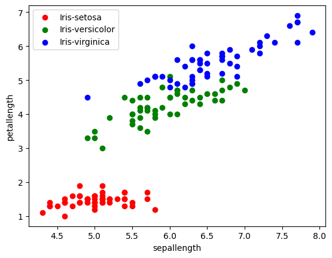

```python
x_index = 0
y_index = 2
for curr_class, color in zip(range(1, 4), 'rgb'):
    scatterplot = plt.scatter(iris_df[iris_df["class"] == curr_class].iloc[:, x_index],
                              iris_df[iris_df["class"] == curr_class].iloc[:, y_index],
                              c = color,
                              # here you can customize the marker size or style, for instance
                              label = dict_names[curr_class])
plt.xlabel(iris_df.columns[x_index])
plt.ylabel(iris_df.columns[y_index])
plt.legend()
plt.show()
```

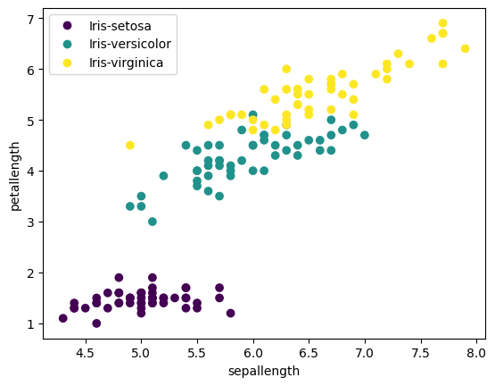

```python
# analogously: easier on the plotting stage, more complicated for handling legend elements.
x_index = 0
y_index = 2

scatterplot = plt.scatter(iris_df.iloc[:, x_index],
                          iris_df.iloc[:, y_index],
                          c = iris_df['class'])
plt.xlabel(iris_df.columns[x_index])
plt.ylabel(iris_df.columns[y_index])
plt.legend(handles = scatterplot.legend_elements()[0],
           labels = dict_names.values())
plt.show()
```

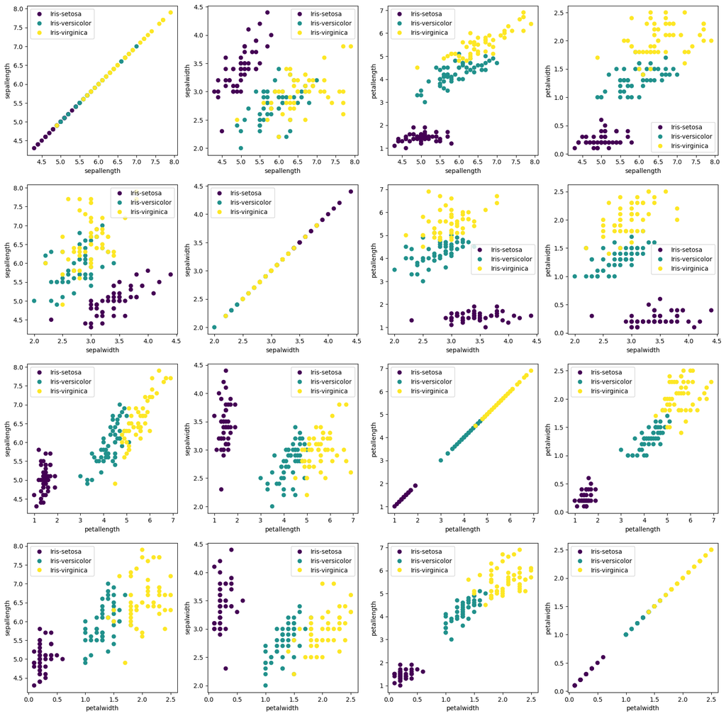

```python
fig, axes = plt.subplots(4, 4, figsize = (20, 20))
for ix in range(4):
    for iy in range(4):
        scatterplot = axes[ix, iy].scatter(iris_df.iloc[:, ix],
                                          iris_df.iloc[:, iy],
                                          c = iris_df['class'])
        axes[ix, iy].set_xlabel(iris_df.columns[ix])
        axes[ix, iy].set_ylabel(iris_df.columns[iy])
        axes[ix, iy].legend(handles = scatterplot.legend_elements()[0],
                            labels = dict_names.values())
```

### Scatter plot with pandas

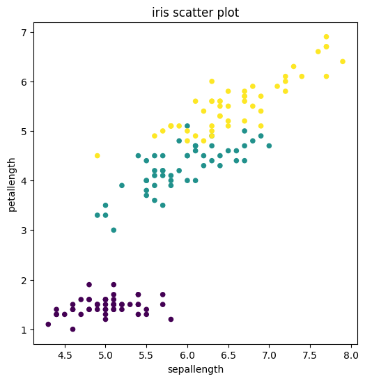

```python
iris_df.plot(x = 'sepallength',
             y = 'petallength',
             kind = 'scatter',
             c = 'class',
             colormap = 'viridis',
             colorbar = False,
             figsize = (6, 6),
             title = 'iris scatter plot')
```

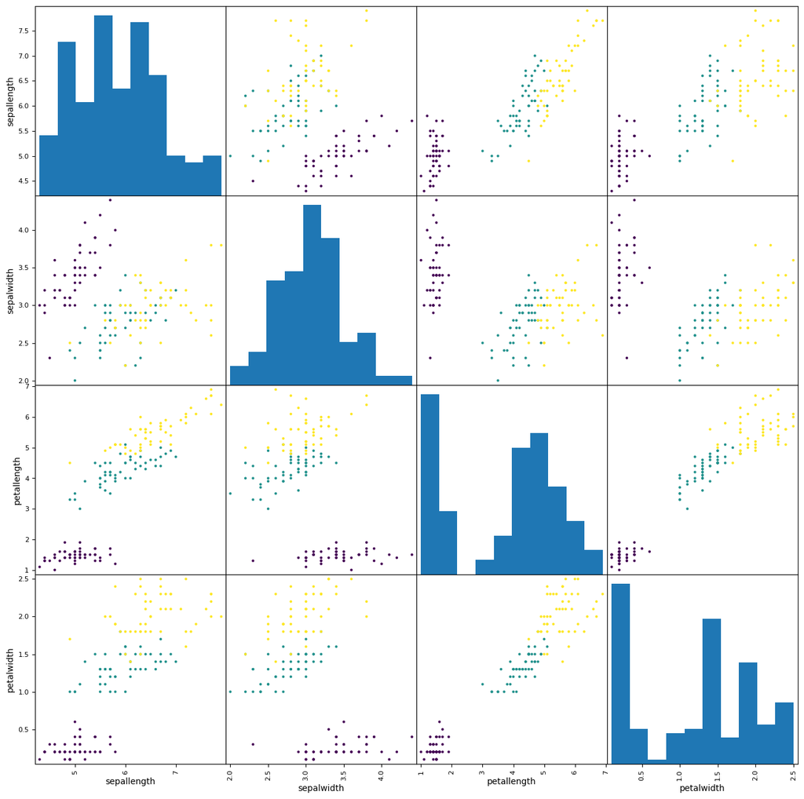

```python
from pandas.plotting import scatter_matrix
scatter_matrix(iris_df.drop('class', axis = 1),
               figsize = (16, 16),
               alpha = 1,
               diagonal = 'hist',
               c = iris_df['class'])
plt.show()
```

### Plotting with Seaborn

```python
import seaborn as sns
```

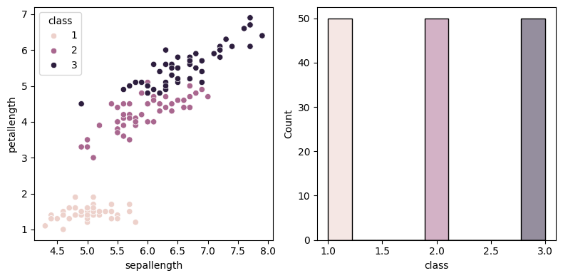

```python
f, axes = plt.subplots(1, 2, figsize = (8, 4))

sns.scatterplot(data = iris_df,
                x = "sepallength",
                y = "petallength",
                hue = "class",
                ax = axes[0])

sns.histplot(data = iris_df,
             x = "class",
             hue = "class",
             legend = False,
             ax = axes[1])
f.tight_layout()
```

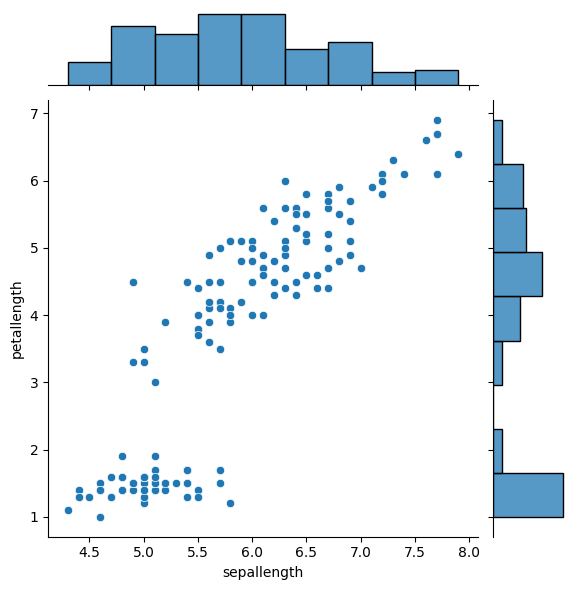

```python
sns.jointplot(data = iris_df,
              x = "sepallength",
              y = "petallength")
```

Assigning a hue variable will add conditional colors to the scatterplot and draw separate density curves on the marginal axes:

internally, it uses `kdeplot()`: it plots univariate or bivariate distributions using kernel density estimation.

- A **kernel density estimate** (KDE) plot is a method for visualizing the distribution of observations in a dataset, analagous to a histogram. KDE represents the data using a continuous probability density curve in one or more dimensions.

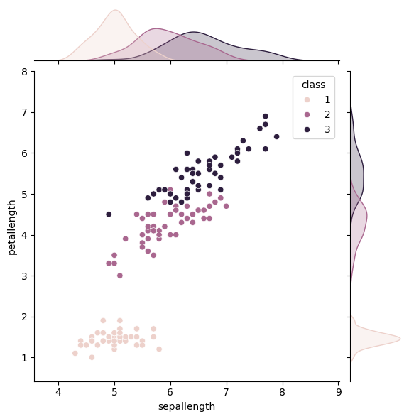

```python
sns.jointplot(data = iris_df,
              x = "sepallength",
              y = "petallength",
              hue = 'class')
```

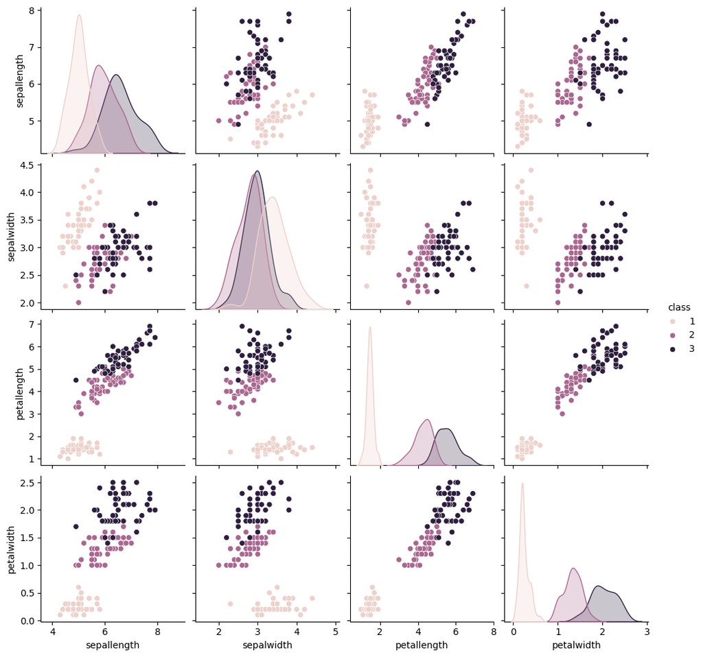

```python
sns.pairplot(data = iris_df,
             hue = "class")
```

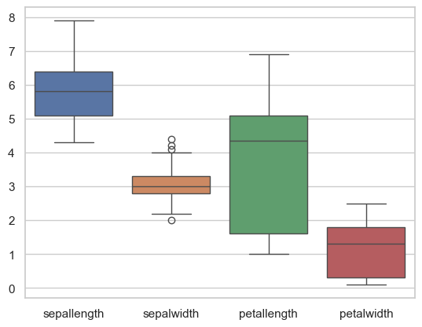

```python
sns.set_theme(style = "whitegrid")
ax = sns.boxplot(data = iris_df.iloc[:, :-1],
                 orient = "v")
```

### Correlation Analysis

`SciPy` is a collection of mathematical algorithms and convenience functions built on the NumPy extension of Python. It adds significant power to the interactive Python session by providing the user with high-level commands and classes for manipulating and visualizing data.

SciPy features includes, but are not limited to:

- statistics
- linear algebra
- fourier transform
- optimization algorithm
- ...

```python
from scipy.stats import pearsonr
pearsonr(iris_df.sepallength, iris_df.sepalwidth)
```

```
PearsonRResult(statistic=np.float64(-0.10936924995064931), pvalue=np.float64(0.18276521527137002))
```

The `pearsonr` function returns:

- Pearson product-moment correlation coefficent.
- The p-value associated with the chosen alternative: it roughly indicates the probability of an uncorrelated system producing datasets that have a Pearson correlation at least as extreme as the one computed from these datasets.

Pearson correlation coefficient can also be obtained with `pandas.DataFrame.corr()`

```python
iris_df.drop('class', axis = 1).corr()
```

|  | sepallength | sepalwidth | petallength | petalwidth |
| --- | --- | --- | --- | --- |
| sepallength | 1.000000 | -0.109369 | 0.871754 | 0.817954 |
| sepalwidth | -0.109369 | 1.000000 | -0.420516 | -0.356544 |
| petallength | 0.871754 | -0.420516 | 1.000000 | 0.962757 |
| petalwidth | 0.817954 | -0.356544 | 0.962757 | 1.000000 |

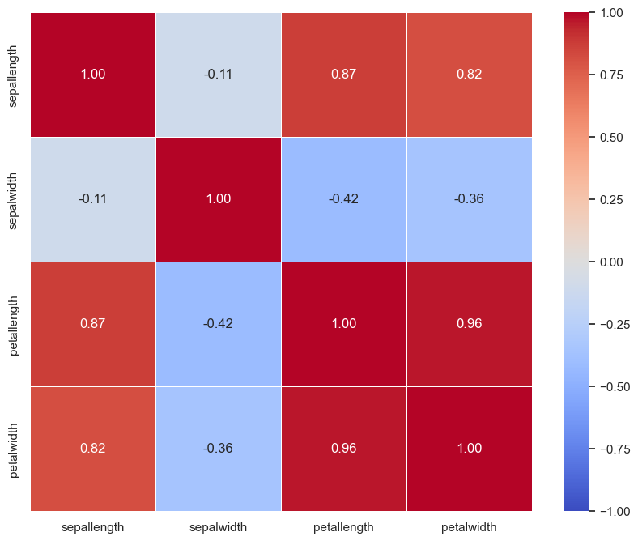

```python
f, ax = plt.subplots(figsize = (10, 8))
sns.heatmap(iris_df.drop('class', axis = 1).corr(),
            annot = True,
            linewidths = .5,
            fmt = '.2f',
            ax = ax,
            vmin = -1,
            vmax = 1,
            cmap = "coolwarm")
plt.show()
```

# Data Exploration (categorical data): the BREAST-CANCER dataset

available at [UCI database](https://archive.ics.uci.edu/ml/datasets/breast+cancer).

This is one of three domains provided by the Oncology Institute that has repeatedly appeared in the machine learning literature. (See also lymphography and primary-tumor.)

This data set includes 286 intances (201 of one class, 85 of another class). The instances are described by 9 attributes, some of which are ordinal and some are nominal.

Attribute information

| column | values |
| --- | --- |
| Class | no-recurrence-events, recurrence-events |
| age | 10-19, 20-29, 30-39, 40-49, 50-59, 60-69, 70-79, 80-89, 90-99 |
| menopause | lt40, ge40, premeno |
| tumor-size | 0-4, 5-9, 10-14, 15-19, 20-24, 25-29, 30-34, 35-39, 40-44, 45-49, 50-54, 55-59 |
| inv-nodes | 0-2, 3-5, 6-8, 9-11, 12-14, 15-17, 18-20, 21-23, 24-26, 27-29, 30-32, 33-35, 36-39 |
| node-caps | yes, no |
| deg-malig | 1, 2, 3 |
| breast | left, right |
| breast-quad | left-up, left-low, right-up, right-low, central |
| irradiat | yes, no |

There are 9 Missing Attribute Values (denoted by "?")

## Load the Dataset

```python
df = pd.read_csv(os.path.join('dataset', 'breast-cancer.csv'))
```

```python
df
```

|  | age | menopause | tumor-size | inv-nodes | node-caps | deg-malig | breast | breast-quad | irradiat | Class |
| --- | --- | --- | --- | --- | --- | --- | --- | --- | --- | --- |
| 0 | '40-49' | 'premeno' | '15-19' | '0-2' | 'yes' | '3' | 'right' | 'left_up' | 'no' | 'recurrence-events' |
| 1 | '50-59' | 'ge40' | '15-19' | '0-2' | 'no' | '1' | 'right' | 'central' | 'no' | 'no-recurrence-events' |
| 2 | '50-59' | 'ge40' | '35-39' | '0-2' | 'no' | '2' | 'left' | 'left_low' | 'no' | 'recurrence-events' |
| 3 | '40-49' | 'premeno' | '35-39' | '0-2' | 'yes' | '3' | 'right' | 'left_low' | 'yes' | 'no-recurrence-events' |
| 4 | '40-49' | 'premeno' | '30-34' | '3-5' | 'yes' | '2' | 'left' | 'right_up' | 'no' | 'recurrence-events' |
| ... | ... | ... | ... | ... | ... | ... | ... | ... | ... | ... |
| 281 | '50-59' | 'ge40' | '30-34' | '6-8' | 'yes' | '2' | 'left' | 'left_low' | 'no' | 'no-recurrence-events' |
| 282 | '50-59' | 'premeno' | '25-29' | '3-5' | 'yes' | '2' | 'left' | 'left_low' | 'yes' | 'no-recurrence-events' |
| 283 | '30-39' | 'premeno' | '30-34' | '6-8' | 'yes' | '2' | 'right' | 'right_up' | 'no' | 'no-recurrence-events' |
| 284 | '50-59' | 'premeno' | '15-19' | '0-2' | 'no' | '2' | 'right' | 'left_low' | 'no' | 'no-recurrence-events' |
| 285 | '50-59' | 'ge40' | '40-44' | '0-2' | 'no' | '3' | 'left' | 'right_up' | 'no' | 'no-recurrence-events' |

286 rows × 10 columns

```python
df.info()
```

```
<class 'pandas.core.frame.DataFrame'>
RangeIndex: 286 entries, 0 to 285
Data columns (total 10 columns):
 #   Column       Non-Null Count  Dtype
---  ------       --------------  -----
 0   age          286 non-null    object
 1   menopause    286 non-null    object
 2   tumor-size   286 non-null    object
 3   inv-nodes    286 non-null    object
 4   node-caps    286 non-null    object
 5   deg-malig    286 non-null    object
 6   breast       286 non-null    object
 7   breast-quad  286 non-null    object
 8   irradiat     286 non-null    object
 9   Class        286 non-null    object
dtypes: object(10)
memory usage: 22.5+ KB
```

**Issue #1**: values are *quoted* using character " **'** "

```python
df = pd.read_csv(os.path.join('dataset', 'breast-cancer.csv'), quotechar = "'")
```

```python
df
```

|  | age | menopause | tumor-size | inv-nodes | node-caps | deg-malig | breast | breast-quad | irradiat | Class |
| --- | --- | --- | --- | --- | --- | --- | --- | --- | --- | --- |
| 0 | 40-49 | premeno | 15-19 | 0-2 | yes | 3 | right | left_up | no | recurrence-events |
| 1 | 50-59 | ge40 | 15-19 | 0-2 | no | 1 | right | central | no | no-recurrence-events |
| 2 | 50-59 | ge40 | 35-39 | 0-2 | no | 2 | left | left_low | no | recurrence-events |
| 3 | 40-49 | premeno | 35-39 | 0-2 | yes | 3 | right | left_low | yes | no-recurrence-events |
| 4 | 40-49 | premeno | 30-34 | 3-5 | yes | 2 | left | right_up | no | recurrence-events |
| ... | ... | ... | ... | ... | ... | ... | ... | ... | ... | ... |
| 281 | 50-59 | ge40 | 30-34 | 6-8 | yes | 2 | left | left_low | no | no-recurrence-events |
| 282 | 50-59 | premeno | 25-29 | 3-5 | yes | 2 | left | left_low | yes | no-recurrence-events |
| 283 | 30-39 | premeno | 30-34 | 6-8 | yes | 2 | right | right_up | no | no-recurrence-events |
| 284 | 50-59 | premeno | 15-19 | 0-2 | no | 2 | right | left_low | no | no-recurrence-events |
| 285 | 50-59 | ge40 | 40-44 | 0-2 | no | 3 | left | right_up | no | no-recurrence-events |

286 rows × 10 columns

```python
df.head(3).T
```

|  | 0 | 1 | 2 |
| --- | --- | --- | --- |
| age | 40-49 | 50-59 | 50-59 |
| menopause | premeno | ge40 | ge40 |
| tumor-size | 15-19 | 15-19 | 35-39 |
| inv-nodes | 0-2 | 0-2 | 0-2 |
| node-caps | yes | no | no |
| deg-malig | 3 | 1 | 2 |
| breast | right | right | left |
| breast-quad | left_up | central | left_low |
| irradiat | no | no | no |
| Class | recurrence-events | no-recurrence-events | recurrence-events |

**Issue #2**: are we handling missing values as such?

```python
df["node-caps"].value_counts()
```

```
node-caps
no     222
yes     56
?        8
Name: count, dtype: int64
```

```python
df = pd.read_csv(os.path.join('dataset',
                              'breast-cancer.csv'),
                 quotechar = "'",
                 na_values = '?')
```

```python
df["node-caps"].value_counts()
```

```
node-caps
no     222
yes     56
Name: count, dtype: int64
```

```python
df["node-caps"].value_counts(dropna = False)
```

```
node-caps
no     222
yes     56
NaN      8
Name: count, dtype: int64
```

## Explore the dataset: Descriptive statistics

```python
df
```

|  | age | menopause | tumor-size | inv-nodes | node-caps | deg-malig | breast | breast-quad | irradiat | Class |
| --- | --- | --- | --- | --- | --- | --- | --- | --- | --- | --- |
| 0 | 40-49 | premeno | 15-19 | 0-2 | yes | 3 | right | left_up | no | recurrence-events |
| 1 | 50-59 | ge40 | 15-19 | 0-2 | no | 1 | right | central | no | no-recurrence-events |
| 2 | 50-59 | ge40 | 35-39 | 0-2 | no | 2 | left | left_low | no | recurrence-events |
| 3 | 40-49 | premeno | 35-39 | 0-2 | yes | 3 | right | left_low | yes | no-recurrence-events |
| 4 | 40-49 | premeno | 30-34 | 3-5 | yes | 2 | left | right_up | no | recurrence-events |
| ... | ... | ... | ... | ... | ... | ... | ... | ... | ... | ... |
| 281 | 50-59 | ge40 | 30-34 | 6-8 | yes | 2 | left | left_low | no | no-recurrence-events |
| 282 | 50-59 | premeno | 25-29 | 3-5 | yes | 2 | left | left_low | yes | no-recurrence-events |
| 283 | 30-39 | premeno | 30-34 | 6-8 | yes | 2 | right | right_up | no | no-recurrence-events |
| 284 | 50-59 | premeno | 15-19 | 0-2 | no | 2 | right | left_low | no | no-recurrence-events |
| 285 | 50-59 | ge40 | 40-44 | 0-2 | no | 3 | left | right_up | no | no-recurrence-events |

286 rows × 10 columns

```python
df.head(10)
```

|  | age | menopause | tumor-size | inv-nodes | node-caps | deg-malig | breast | breast-quad | irradiat | Class |
| --- | --- | --- | --- | --- | --- | --- | --- | --- | --- | --- |
| 0 | 40-49 | premeno | 15-19 | 0-2 | yes | 3 | right | left_up | no | recurrence-events |
| 1 | 50-59 | ge40 | 15-19 | 0-2 | no | 1 | right | central | no | no-recurrence-events |
| 2 | 50-59 | ge40 | 35-39 | 0-2 | no | 2 | left | left_low | no | recurrence-events |
| 3 | 40-49 | premeno | 35-39 | 0-2 | yes | 3 | right | left_low | yes | no-recurrence-events |
| 4 | 40-49 | premeno | 30-34 | 3-5 | yes | 2 | left | right_up | no | recurrence-events |
| 5 | 50-59 | premeno | 25-29 | 3-5 | no | 2 | right | left_up | yes | no-recurrence-events |
| 6 | 50-59 | ge40 | 40-44 | 0-2 | no | 3 | left | left_up | no | no-recurrence-events |
| 7 | 40-49 | premeno | 10-14 | 0-2 | no | 2 | left | left_up | no | no-recurrence-events |
| 8 | 40-49 | premeno | 0-4 | 0-2 | no | 2 | right | right_low | no | no-recurrence-events |
| 9 | 40-49 | ge40 | 40-44 | 15-17 | yes | 2 | right | left_up | yes | no-recurrence-events |

```python
df.head(2).T
```

|  | 0 | 1 |
| --- | --- | --- |
| age | 40-49 | 50-59 |
| menopause | premeno | ge40 |
| tumor-size | 15-19 | 15-19 |
| inv-nodes | 0-2 | 0-2 |
| node-caps | yes | no |
| deg-malig | 3 | 1 |
| breast | right | right |
| breast-quad | left_up | central |
| irradiat | no | no |
| Class | recurrence-events | no-recurrence-events |

```python
df.shape
```

```
(286, 10)
```

Check if there is any missing value

```python
df.isna().sum()
```

```
age            0
menopause      0
tumor-size     0
inv-nodes      0
node-caps      8
deg-malig      0
breast         0
breast-quad    1
irradiat       0
Class          0
dtype: int64
```

```python
df[df.isna().any(axis=1)]
```

|  | age | menopause | tumor-size | inv-nodes | node-caps | deg-malig | breast | breast-quad | irradiat | Class |
| --- | --- | --- | --- | --- | --- | --- | --- | --- | --- | --- |
| 20 | 50-59 | lt40 | 20-24 | 0-2 | NaN | 1 | left | left_low | no | recurrence-events |
| 31 | 60-69 | ge40 | 25-29 | 3-5 | NaN | 1 | right | left_low | yes | no-recurrence-events |
| 50 | 70-79 | ge40 | 15-19 | 9-11 | NaN | 1 | left | left_low | yes | recurrence-events |
| 54 | 40-49 | premeno | 25-29 | 0-2 | NaN | 2 | left | right_low | yes | no-recurrence-events |
| 71 | 60-69 | ge40 | 25-29 | 3-5 | NaN | 1 | right | left_up | yes | no-recurrence-events |
| 92 | 50-59 | lt40 | 20-24 | 0-2 | NaN | 1 | left | left_up | no | recurrence-events |
| 149 | 50-59 | ge40 | 30-34 | 9-11 | NaN | 3 | left | left_up | yes | no-recurrence-events |
| 240 | 50-59 | ge40 | 30-34 | 0-2 | no | 3 | left | NaN | no | recurrence-events |
| 264 | 50-59 | ge40 | 30-34 | 9-11 | NaN | 3 | left | left_low | yes | no-recurrence-events |

```python
df.age.unique()
```

```
array(['40-49', '50-59', '60-69', '30-39', '70-79', '20-29'], dtype=object)
```

```python
df.info()
```

```
<class 'pandas.core.frame.DataFrame'>
RangeIndex: 286 entries, 0 to 285
Data columns (total 10 columns):
 #   Column       Non-Null Count  Dtype
---  ------       --------------  -----
 0   age          286 non-null    object
 1   menopause    286 non-null    object
 2   tumor-size   286 non-null    object
 3   inv-nodes    286 non-null    object
 4   node-caps    278 non-null    object
 5   deg-malig    286 non-null    int64
 6   breast       286 non-null    object
 7   breast-quad  285 non-null    object
 8   irradiat     286 non-null    object
 9   Class        286 non-null    object
dtypes: int64(1), object(9)
memory usage: 22.5+ KB
```

Most columns are recognized as generic "object" (text or mixed numeric and non-numeric values). Actually, we know from the documentation that we are dealing with categorical variables.

`Pandas` has a **categorical** data type, which may be useful in the following cases:

- A string variable consisting of only a few different values. Converting such a string variable to a categorical variable will save some memory.
- The lexical order of a variable is not the same as the logical order (“one”, “two”, “three”). By converting to a categorical and specifying an order on the categories, sorting and min/max will use the logical order instead of the lexical order, see here.
- As a signal to other Python libraries that this column should be treated as a categorical variable (e.g. to use suitable statistical methods or plot types).

`Categoricals` are a pandas data type corresponding to categorical variables in statistics. A categorical variable takes on a limited, and usually fixed, number of possible values (categories). Examples are gender, social class, blood type, country affiliation, observation time or rating via Likert scales.

In contrast to statistical categorical variables, categorical data might have an order (e.g. 'strongly agree' vs 'agree' or 'first observation' vs. 'second observation'), but numerical operations (additions, divisions, …) are not possible.

```python
df.describe()
```

|  | deg-malig |
| --- | --- |
| count | 286.000000 |
| mean | 2.048951 |
| std | 0.738217 |
| min | 1.000000 |
| 25% | 2.000000 |
| 50% | 2.000000 |
| 75% | 3.000000 |
| max | 3.000000 |

By default, describe considers only numeric data

```python
df.describe(include = 'object')
```

|  | age | menopause | tumor-size | inv-nodes | node-caps | breast | breast-quad | irradiat | Class |
| --- | --- | --- | --- | --- | --- | --- | --- | --- | --- |
| count | 286 | 286 | 286 | 286 | 278 | 286 | 285 | 286 | 286 |
| unique | 6 | 3 | 11 | 7 | 2 | 2 | 5 | 2 | 2 |
| top | 50-59 | premeno | 30-34 | 0-2 | no | left | left_low | no | no-recurrence-events |
| freq | 96 | 150 | 60 | 213 | 222 | 152 | 110 | 218 | 201 |

```python
df.describe(include = 'all') # mixed data type: description still supported
```

|  | age | menopause | tumor-size | inv-nodes | node-caps | deg-malig | breast | breast-quad | irradiat | Class |
| --- | --- | --- | --- | --- | --- | --- | --- | --- | --- | --- |
| count | 286 | 286 | 286 | 286 | 278 | 286.000000 | 286 | 285 | 286 | 286 |
| unique | 6 | 3 | 11 | 7 | 2 | NaN | 2 | 5 | 2 | 2 |
| top | 50-59 | premeno | 30-34 | 0-2 | no | NaN | left | left_low | no | no-recurrence-events |
| freq | 96 | 150 | 60 | 213 | 222 | NaN | 152 | 110 | 218 | 201 |
| mean | NaN | NaN | NaN | NaN | NaN | 2.048951 | NaN | NaN | NaN | NaN |
| std | NaN | NaN | NaN | NaN | NaN | 0.738217 | NaN | NaN | NaN | NaN |
| min | NaN | NaN | NaN | NaN | NaN | 1.000000 | NaN | NaN | NaN | NaN |
| 25% | NaN | NaN | NaN | NaN | NaN | 2.000000 | NaN | NaN | NaN | NaN |
| 50% | NaN | NaN | NaN | NaN | NaN | 2.000000 | NaN | NaN | NaN | NaN |
| 75% | NaN | NaN | NaN | NaN | NaN | 3.000000 | NaN | NaN | NaN | NaN |
| max | NaN | NaN | NaN | NaN | NaN | 3.000000 | NaN | NaN | NaN | NaN |

We can cast our dataframe to categorical, as we know that this is the case.

```python
df = df.astype('category')
```

```python
df.info()
```

```
<class 'pandas.core.frame.DataFrame'>
RangeIndex: 286 entries, 0 to 285
Data columns (total 10 columns):
 #   Column       Non-Null Count  Dtype
---  ------       --------------  -----
 0   age          286 non-null    category
 1   menopause    286 non-null    category
 2   tumor-size   286 non-null    category
 3   inv-nodes    286 non-null    category
 4   node-caps    278 non-null    category
 5   deg-malig    286 non-null    category
 6   breast       286 non-null    category
 7   breast-quad  285 non-null    category
 8   irradiat     286 non-null    category
 9   Class        286 non-null    category
dtypes: category(10)
memory usage: 4.8 KB
```

```python
df.describe()
```

|  | age | menopause | tumor-size | inv-nodes | node-caps | deg-malig | breast | breast-quad | irradiat | Class |
| --- | --- | --- | --- | --- | --- | --- | --- | --- | --- | --- |
| count | 286 | 286 | 286 | 286 | 278 | 286 | 286 | 285 | 286 | 286 |
| unique | 6 | 3 | 11 | 7 | 2 | 3 | 2 | 5 | 2 | 2 |
| top | 50-59 | premeno | 30-34 | 0-2 | no | 2 | left | left_low | no | no-recurrence-events |
| freq | 96 | 150 | 60 | 213 | 222 | 130 | 152 | 110 | 218 | 201 |

```python
pd.set_option('display.max_rows', None)
df.sort_values(by = 'inv-nodes').tail(80)
```

|  | age | menopause | tumor-size | inv-nodes | node-caps | deg-malig | breast | breast-quad | irradiat | Class |
| --- | --- | --- | --- | --- | --- | --- | --- | --- | --- | --- |
| 95 | 40-49 | premeno | 45-49 | 0-2 | no | 2 | left | left_low | yes | no-recurrence-events |
| 92 | 50-59 | lt40 | 20-24 | 0-2 | NaN | 1 | left | left_up | no | recurrence-events |
| 97 | 50-59 | premeno | 10-14 | 0-2 | no | 1 | left | left_low | no | no-recurrence-events |
| 89 | 50-59 | ge40 | 30-34 | 0-2 | no | 1 | left | left_up | no | no-recurrence-events |
| 7 | 40-49 | premeno | 10-14 | 0-2 | no | 2 | left | left_up | no | no-recurrence-events |
| 88 | 50-59 | ge40 | 20-24 | 0-2 | no | 1 | right | left_low | no | no-recurrence-events |
| 96 | 30-39 | premeno | 40-44 | 0-2 | no | 1 | left | left_up | no | recurrence-events |
| 237 | 40-49 | premeno | 30-34 | 12-14 | yes | 3 | left | left_up | yes | recurrence-events |
| 210 | 40-49 | ge40 | 25-29 | 12-14 | yes | 3 | left | right_low | yes | recurrence-events |
| 198 | 40-49 | premeno | 15-19 | 12-14 | no | 3 | right | right_low | yes | no-recurrence-events |
| 29 | 40-49 | premeno | 15-19 | 15-17 | yes | 3 | left | left_low | no | recurrence-events |
| 57 | 50-59 | ge40 | 35-39 | 15-17 | no | 3 | left | left_low | no | no-recurrence-events |
| 55 | 50-59 | ge40 | 25-29 | 15-17 | yes | 3 | right | left_up | no | no-recurrence-events |
| 271 | 50-59 | premeno | 35-39 | 15-17 | yes | 3 | right | right_up | no | recurrence-events |
| 9 | 40-49 | ge40 | 40-44 | 15-17 | yes | 2 | right | left_up | yes | no-recurrence-events |
| 63 | 40-49 | premeno | 30-34 | 15-17 | yes | 3 | left | left_low | no | recurrence-events |
| 140 | 60-69 | ge40 | 20-24 | 24-26 | yes | 3 | left | left_low | yes | recurrence-events |
| 263 | 40-49 | premeno | 20-24 | 3-5 | yes | 2 | right | right_up | yes | recurrence-events |
| 21 | 60-69 | ge40 | 40-44 | 3-5 | no | 2 | right | left_up | yes | no-recurrence-events |
| 4 | 40-49 | premeno | 30-34 | 3-5 | yes | 2 | left | right_up | no | recurrence-events |
| 31 | 60-69 | ge40 | 25-29 | 3-5 | NaN | 1 | right | left_low | yes | no-recurrence-events |
| 5 | 50-59 | premeno | 25-29 | 3-5 | no | 2 | right | left_up | yes | no-recurrence-events |
| 25 | 50-59 | ge40 | 20-24 | 3-5 | yes | 2 | right | left_up | no | no-recurrence-events |
| 282 | 50-59 | premeno | 25-29 | 3-5 | yes | 2 | left | left_low | yes | no-recurrence-events |
| 16 | 50-59 | premeno | 10-14 | 3-5 | no | 1 | right | left_up | no | no-recurrence-events |
| 272 | 30-39 | premeno | 20-24 | 3-5 | yes | 2 | right | left_up | yes | no-recurrence-events |
| 258 | 40-49 | premeno | 30-34 | 3-5 | yes | 2 | right | left_low | no | no-recurrence-events |
| 278 | 50-59 | premeno | 30-34 | 3-5 | yes | 2 | left | left_low | yes | no-recurrence-events |
| 28 | 60-69 | ge40 | 30-34 | 3-5 | yes | 3 | left | left_low | no | no-recurrence-events |
| 142 | 40-49 | premeno | 30-34 | 3-5 | no | 2 | right | left_up | no | recurrence-events |
| 143 | 50-59 | premeno | 20-24 | 3-5 | yes | 2 | left | left_low | no | no-recurrence-events |
| 171 | 50-59 | ge40 | 30-34 | 3-5 | no | 3 | right | left_up | no | recurrence-events |
| 174 | 40-49 | premeno | 40-44 | 3-5 | yes | 3 | right | left_up | yes | no-recurrence-events |
| 176 | 40-49 | premeno | 20-24 | 3-5 | no | 2 | right | left_up | no | no-recurrence-events |
| 105 | 60-69 | ge40 | 30-34 | 3-5 | yes | 2 | left | central | yes | recurrence-events |
| 113 | 30-39 | premeno | 40-44 | 3-5 | no | 3 | right | right_up | yes | no-recurrence-events |
| 183 | 50-59 | ge40 | 30-34 | 3-5 | no | 3 | left | left_low | no | recurrence-events |
| 91 | 30-39 | premeno | 30-34 | 3-5 | no | 3 | right | left_up | yes | recurrence-events |
| 160 | 50-59 | ge40 | 25-29 | 3-5 | yes | 3 | right | left_up | no | no-recurrence-events |
| 157 | 30-39 | premeno | 20-24 | 3-5 | yes | 2 | left | left_low | no | recurrence-events |
| 153 | 30-39 | premeno | 25-29 | 3-5 | yes | 3 | left | left_low | yes | recurrence-events |
| 164 | 40-49 | ge40 | 20-24 | 3-5 | no | 3 | right | left_low | yes | recurrence-events |
| 166 | 60-69 | ge40 | 25-29 | 3-5 | no | 2 | right | right_up | no | recurrence-events |
| 70 | 50-59 | premeno | 25-29 | 3-5 | yes | 3 | left | left_low | yes | recurrence-events |
| 195 | 30-39 | premeno | 20-24 | 3-5 | no | 2 | right | central | no | no-recurrence-events |
| 152 | 50-59 | ge40 | 40-44 | 3-5 | yes | 2 | left | left_low | no | no-recurrence-events |
| 205 | 60-69 | ge40 | 40-44 | 3-5 | yes | 3 | right | left_low | no | recurrence-events |
| 106 | 60-69 | ge40 | 20-24 | 3-5 | no | 2 | left | left_low | yes | recurrence-events |
| 208 | 40-49 | ge40 | 30-34 | 3-5 | no | 3 | left | left_low | no | recurrence-events |
| 100 | 40-49 | premeno | 20-24 | 3-5 | yes | 2 | left | left_low | yes | recurrence-events |
| 222 | 40-49 | premeno | 20-24 | 3-5 | no | 2 | right | left_low | no | no-recurrence-events |
| 43 | 50-59 | ge40 | 20-24 | 3-5 | yes | 3 | right | right_up | no | recurrence-events |
| 71 | 60-69 | ge40 | 25-29 | 3-5 | NaN | 1 | right | left_up | yes | no-recurrence-events |
| 161 | 40-49 | premeno | 30-34 | 6-8 | no | 2 | left | left_up | no | no-recurrence-events |
| 273 | 40-49 | premeno | 20-24 | 6-8 | no | 2 | right | left_low | yes | no-recurrence-events |
| 270 | 50-59 | ge40 | 25-29 | 6-8 | no | 3 | left | left_low | yes | recurrence-events |
| 87 | 30-39 | premeno | 25-29 | 6-8 | yes | 2 | right | left_up | yes | no-recurrence-events |
| 37 | 60-69 | ge40 | 45-49 | 6-8 | yes | 3 | left | central | no | no-recurrence-events |
| 181 | 60-69 | ge40 | 10-14 | 6-8 | yes | 3 | left | left_up | yes | recurrence-events |
| 79 | 60-69 | ge40 | 30-34 | 6-8 | yes | 2 | right | right_up | no | no-recurrence-events |
| 74 | 30-39 | premeno | 25-29 | 6-8 | yes | 3 | left | right_low | yes | recurrence-events |
| 73 | 50-59 | ge40 | 30-34 | 6-8 | yes | 3 | left | right_low | no | recurrence-events |
| 281 | 50-59 | ge40 | 30-34 | 6-8 | yes | 2 | left | left_low | no | no-recurrence-events |
| 192 | 60-69 | ge40 | 35-39 | 6-8 | yes | 3 | left | left_low | no | recurrence-events |
| 24 | 30-39 | premeno | 15-19 | 6-8 | yes | 3 | left | left_low | yes | recurrence-events |
| 60 | 50-59 | ge40 | 40-44 | 6-8 | yes | 3 | left | left_low | yes | recurrence-events |
| 283 | 30-39 | premeno | 30-34 | 6-8 | yes | 2 | right | right_up | no | no-recurrence-events |
| 239 | 50-59 | ge40 | 40-44 | 6-8 | yes | 3 | left | left_low | yes | recurrence-events |
| 165 | 50-59 | ge40 | 30-34 | 6-8 | yes | 2 | left | right_low | yes | recurrence-events |
| 116 | 40-49 | premeno | 30-34 | 6-8 | yes | 3 | right | left_up | no | recurrence-events |
| 118 | 40-49 | premeno | 35-39 | 9-11 | yes | 2 | right | left_up | yes | no-recurrence-events |
| 41 | 40-49 | premeno | 35-39 | 9-11 | yes | 2 | right | right_up | yes | no-recurrence-events |
| 149 | 50-59 | ge40 | 30-34 | 9-11 | NaN | 3 | left | left_up | yes | no-recurrence-events |
| 264 | 50-59 | ge40 | 30-34 | 9-11 | NaN | 3 | left | left_low | yes | no-recurrence-events |
| 177 | 40-49 | premeno | 25-29 | 9-11 | yes | 3 | right | left_up | no | recurrence-events |
| 250 | 50-59 | ge40 | 30-34 | 9-11 | yes | 3 | left | right_low | yes | recurrence-events |
| 68 | 50-59 | premeno | 50-54 | 9-11 | yes | 2 | right | left_up | no | recurrence-events |
| 50 | 70-79 | ge40 | 15-19 | 9-11 | NaN | 1 | left | left_low | yes | recurrence-events |
| 146 | 30-39 | premeno | 30-34 | 9-11 | no | 2 | right | left_up | yes | recurrence-events |
| 123 | 30-39 | premeno | 35-39 | 9-11 | yes | 3 | left | left_low | no | recurrence-events |

**Another issue**: we are not using the proper order as the lexical one is not the same as the logical one: for example (0-2 < 3-5 < 10-12) but ("0-2" < "10-12" < "3-5")

```python
from pandas.api.types import CategoricalDtype
# the following categories are available in the dataset description ("attribute information") at the beginning of this notebook
categories = CategoricalDtype(["0-2",
                               "3-5",
                               "6-8",
                               "9-11",
                               "12-14",
                               "15-17",
                               "18-20",
                               "21-23",
                               "24-26",
                               "27-29",
                               "30-32",
                               "33-35",
                               "36-39"],
                              ordered = True)
# Inv-nodes: the number (range 0 - 39) of axillary lymph nodes
# that contain metastatic breast cancer visible on histological examination.
df['inv-nodes'] = df['inv-nodes'].astype(categories)
```

```python
df.info()
```

```
<class 'pandas.core.frame.DataFrame'>
RangeIndex: 286 entries, 0 to 285
Data columns (total 10 columns):
 #   Column       Non-Null Count  Dtype
---  ------       --------------  -----
 0   age          286 non-null    category
 1   menopause    286 non-null    category
 2   tumor-size   286 non-null    category
 3   inv-nodes    286 non-null    category
 4   node-caps    278 non-null    category
 5   deg-malig    286 non-null    category
 6   breast       286 non-null    category
 7   breast-quad  285 non-null    category
 8   irradiat     286 non-null    category
 9   Class        286 non-null    category
dtypes: category(10)
memory usage: 5.1 KB
```

```python
df.sort_values(by = 'inv-nodes').tail(80)
```

|  | age | menopause | tumor-size | inv-nodes | node-caps | deg-malig | breast | breast-quad | irradiat | Class |
| --- | --- | --- | --- | --- | --- | --- | --- | --- | --- | --- |
| 93 | 50-59 | premeno | 10-14 | 0-2 | no | 2 | right | left_up | no | no-recurrence-events |
| 94 | 50-59 | ge40 | 20-24 | 0-2 | no | 2 | right | left_up | no | no-recurrence-events |
| 11 | 60-69 | ge40 | 15-19 | 0-2 | no | 2 | right | left_up | no | no-recurrence-events |
| 95 | 40-49 | premeno | 45-49 | 0-2 | no | 2 | left | left_low | yes | no-recurrence-events |
| 96 | 30-39 | premeno | 40-44 | 0-2 | no | 1 | left | left_up | no | recurrence-events |
| 97 | 50-59 | premeno | 10-14 | 0-2 | no | 1 | left | left_low | no | no-recurrence-events |
| 12 | 50-59 | ge40 | 30-34 | 0-2 | no | 1 | right | central | no | no-recurrence-events |
| 282 | 50-59 | premeno | 25-29 | 3-5 | yes | 2 | left | left_low | yes | no-recurrence-events |
| 43 | 50-59 | ge40 | 20-24 | 3-5 | yes | 3 | right | right_up | no | recurrence-events |
| 16 | 50-59 | premeno | 10-14 | 3-5 | no | 1 | right | left_up | no | no-recurrence-events |
| 4 | 40-49 | premeno | 30-34 | 3-5 | yes | 2 | left | right_up | no | recurrence-events |
| 5 | 50-59 | premeno | 25-29 | 3-5 | no | 2 | right | left_up | yes | no-recurrence-events |
| 31 | 60-69 | ge40 | 25-29 | 3-5 | NaN | 1 | right | left_low | yes | no-recurrence-events |
| 28 | 60-69 | ge40 | 30-34 | 3-5 | yes | 3 | left | left_low | no | no-recurrence-events |
| 25 | 50-59 | ge40 | 20-24 | 3-5 | yes | 2 | right | left_up | no | no-recurrence-events |
| 263 | 40-49 | premeno | 20-24 | 3-5 | yes | 2 | right | right_up | yes | recurrence-events |
| 21 | 60-69 | ge40 | 40-44 | 3-5 | no | 2 | right | left_up | yes | no-recurrence-events |
| 258 | 40-49 | premeno | 30-34 | 3-5 | yes | 2 | right | left_low | no | no-recurrence-events |
| 278 | 50-59 | premeno | 30-34 | 3-5 | yes | 2 | left | left_low | yes | no-recurrence-events |
| 272 | 30-39 | premeno | 20-24 | 3-5 | yes | 2 | right | left_up | yes | no-recurrence-events |
| 142 | 40-49 | premeno | 30-34 | 3-5 | no | 2 | right | left_up | no | recurrence-events |
| 171 | 50-59 | ge40 | 30-34 | 3-5 | no | 3 | right | left_up | no | recurrence-events |
| 153 | 30-39 | premeno | 25-29 | 3-5 | yes | 3 | left | left_low | yes | recurrence-events |
| 157 | 30-39 | premeno | 20-24 | 3-5 | yes | 2 | left | left_low | no | recurrence-events |
| 160 | 50-59 | ge40 | 25-29 | 3-5 | yes | 3 | right | left_up | no | no-recurrence-events |
| 91 | 30-39 | premeno | 30-34 | 3-5 | no | 3 | right | left_up | yes | recurrence-events |
| 164 | 40-49 | ge40 | 20-24 | 3-5 | no | 3 | right | left_low | yes | recurrence-events |
| 166 | 60-69 | ge40 | 25-29 | 3-5 | no | 2 | right | right_up | no | recurrence-events |
| 222 | 40-49 | premeno | 20-24 | 3-5 | no | 2 | right | left_low | no | no-recurrence-events |
| 174 | 40-49 | premeno | 40-44 | 3-5 | yes | 3 | right | left_up | yes | no-recurrence-events |
| 176 | 40-49 | premeno | 20-24 | 3-5 | no | 2 | right | left_up | no | no-recurrence-events |
| 100 | 40-49 | premeno | 20-24 | 3-5 | yes | 2 | left | left_low | yes | recurrence-events |
| 183 | 50-59 | ge40 | 30-34 | 3-5 | no | 3 | left | left_low | no | recurrence-events |
| 71 | 60-69 | ge40 | 25-29 | 3-5 | NaN | 1 | right | left_up | yes | no-recurrence-events |
| 70 | 50-59 | premeno | 25-29 | 3-5 | yes | 3 | left | left_low | yes | recurrence-events |
| 152 | 50-59 | ge40 | 40-44 | 3-5 | yes | 2 | left | left_low | no | no-recurrence-events |
| 143 | 50-59 | premeno | 20-24 | 3-5 | yes | 2 | left | left_low | no | no-recurrence-events |
| 208 | 40-49 | ge40 | 30-34 | 3-5 | no | 3 | left | left_low | no | recurrence-events |
| 195 | 30-39 | premeno | 20-24 | 3-5 | no | 2 | right | central | no | no-recurrence-events |
| 113 | 30-39 | premeno | 40-44 | 3-5 | no | 3 | right | right_up | yes | no-recurrence-events |
| 106 | 60-69 | ge40 | 20-24 | 3-5 | no | 2 | left | left_low | yes | recurrence-events |
| 105 | 60-69 | ge40 | 30-34 | 3-5 | yes | 2 | left | central | yes | recurrence-events |
| 205 | 60-69 | ge40 | 40-44 | 3-5 | yes | 3 | right | left_low | no | recurrence-events |
| 79 | 60-69 | ge40 | 30-34 | 6-8 | yes | 2 | right | right_up | no | no-recurrence-events |
| 283 | 30-39 | premeno | 30-34 | 6-8 | yes | 2 | right | right_up | no | no-recurrence-events |
| 270 | 50-59 | ge40 | 25-29 | 6-8 | no | 3 | left | left_low | yes | recurrence-events |
| 281 | 50-59 | ge40 | 30-34 | 6-8 | yes | 2 | left | left_low | no | no-recurrence-events |
| 161 | 40-49 | premeno | 30-34 | 6-8 | no | 2 | left | left_up | no | no-recurrence-events |
| 116 | 40-49 | premeno | 30-34 | 6-8 | yes | 3 | right | left_up | no | recurrence-events |
| 165 | 50-59 | ge40 | 30-34 | 6-8 | yes | 2 | left | right_low | yes | recurrence-events |
| 24 | 30-39 | premeno | 15-19 | 6-8 | yes | 3 | left | left_low | yes | recurrence-events |
| 37 | 60-69 | ge40 | 45-49 | 6-8 | yes | 3 | left | central | no | no-recurrence-events |
| 60 | 50-59 | ge40 | 40-44 | 6-8 | yes | 3 | left | left_low | yes | recurrence-events |
| 239 | 50-59 | ge40 | 40-44 | 6-8 | yes | 3 | left | left_low | yes | recurrence-events |
| 192 | 60-69 | ge40 | 35-39 | 6-8 | yes | 3 | left | left_low | no | recurrence-events |
| 73 | 50-59 | ge40 | 30-34 | 6-8 | yes | 3 | left | right_low | no | recurrence-events |
| 181 | 60-69 | ge40 | 10-14 | 6-8 | yes | 3 | left | left_up | yes | recurrence-events |
| 273 | 40-49 | premeno | 20-24 | 6-8 | no | 2 | right | left_low | yes | no-recurrence-events |
| 87 | 30-39 | premeno | 25-29 | 6-8 | yes | 2 | right | left_up | yes | no-recurrence-events |
| 74 | 30-39 | premeno | 25-29 | 6-8 | yes | 3 | left | right_low | yes | recurrence-events |
| 146 | 30-39 | premeno | 30-34 | 9-11 | no | 2 | right | left_up | yes | recurrence-events |
| 149 | 50-59 | ge40 | 30-34 | 9-11 | NaN | 3 | left | left_up | yes | no-recurrence-events |
| 118 | 40-49 | premeno | 35-39 | 9-11 | yes | 2 | right | left_up | yes | no-recurrence-events |
| 50 | 70-79 | ge40 | 15-19 | 9-11 | NaN | 1 | left | left_low | yes | recurrence-events |
| 264 | 50-59 | ge40 | 30-34 | 9-11 | NaN | 3 | left | left_low | yes | no-recurrence-events |
| 177 | 40-49 | premeno | 25-29 | 9-11 | yes | 3 | right | left_up | no | recurrence-events |
| 250 | 50-59 | ge40 | 30-34 | 9-11 | yes | 3 | left | right_low | yes | recurrence-events |
| 68 | 50-59 | premeno | 50-54 | 9-11 | yes | 2 | right | left_up | no | recurrence-events |
| 41 | 40-49 | premeno | 35-39 | 9-11 | yes | 2 | right | right_up | yes | no-recurrence-events |
| 123 | 30-39 | premeno | 35-39 | 9-11 | yes | 3 | left | left_low | no | recurrence-events |
| 198 | 40-49 | premeno | 15-19 | 12-14 | no | 3 | right | right_low | yes | no-recurrence-events |
| 237 | 40-49 | premeno | 30-34 | 12-14 | yes | 3 | left | left_up | yes | recurrence-events |
| 210 | 40-49 | ge40 | 25-29 | 12-14 | yes | 3 | left | right_low | yes | recurrence-events |
| 271 | 50-59 | premeno | 35-39 | 15-17 | yes | 3 | right | right_up | no | recurrence-events |
| 29 | 40-49 | premeno | 15-19 | 15-17 | yes | 3 | left | left_low | no | recurrence-events |
| 63 | 40-49 | premeno | 30-34 | 15-17 | yes | 3 | left | left_low | no | recurrence-events |
| 57 | 50-59 | ge40 | 35-39 | 15-17 | no | 3 | left | left_low | no | no-recurrence-events |
| 55 | 50-59 | ge40 | 25-29 | 15-17 | yes | 3 | right | left_up | no | no-recurrence-events |
| 9 | 40-49 | ge40 | 40-44 | 15-17 | yes | 2 | right | left_up | yes | no-recurrence-events |
| 140 | 60-69 | ge40 | 20-24 | 24-26 | yes | 3 | left | left_low | yes | recurrence-events |

## Explore the dataset: Visualization

*Barplot* and *pie-chart* in pandas (shown just for an attribute, but applies to all)

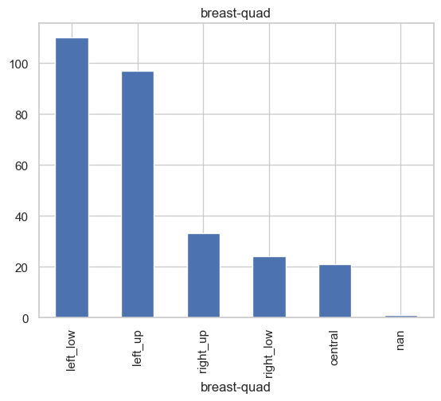

```python
value_count = df['breast-quad'].value_counts(dropna = False)
value_count.plot(kind = 'bar')
plt.title('breast-quad')
plt.show()
```

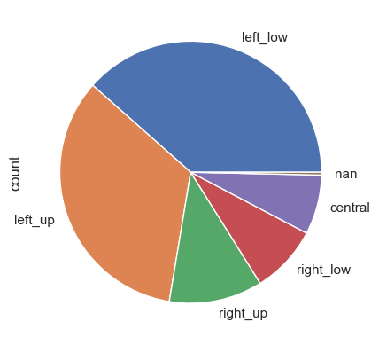

```python
value_count.plot(kind = "pie")
plt.show()
```

*Barplot* in seaborn.

`seaborn` axes-level functions for [plotting categorical data](https://seaborn.pydata.org/tutorial/categorical.html):

- categorical scatter plots
  - `stripplot()`
  - `swarmplot()`
- distribution plots
  - `boxplot()`
  - `violinplot()`
  - `boxenplot()`
- estimate plots
  - `pointplot()`
  - `barplot()`
  - `countplot()`

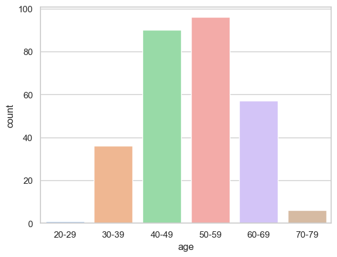

```python
sns.countplot(x = "age",
              hue = "age",
              data = df,
              palette = "pastel",
              legend = False)
plt.show()
```

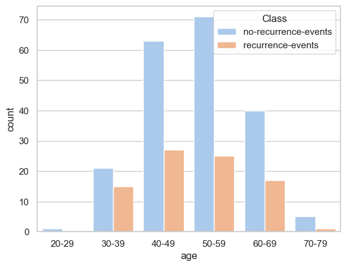

```python
sns.countplot(x = "age",
              data = df,
              hue = "Class",
              palette = "pastel")
plt.show()
```

`seaborn` also provides a figure-level interface, `catplot()`, that gives unified higher-level access to the axes-level functions.

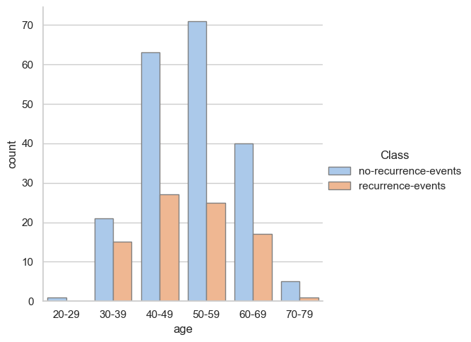

```python
sns.catplot(x = "age",
            # x = 'age' --> vertical
            hue = "Class",
            kind = "count",
            palette = "pastel",
            edgecolor = ".5",
            data = df)
```

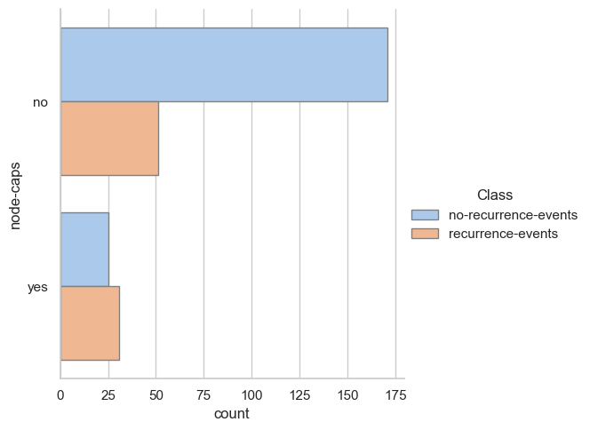

```python
sns.catplot(y = "node-caps",
            # y = 'node-caps' --> horizontal
            hue = "Class",
            kind = "count",
            palette = "pastel",
            edgecolor = ".5",
            data = df)
```

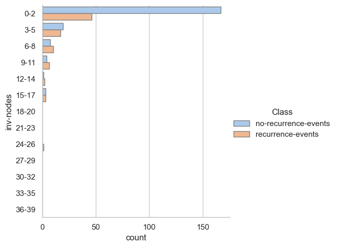

```python
sns.catplot(y = "inv-nodes",
            hue = "Class",
            kind = "count",
            palette = "pastel",
            edgecolor = ".5",
            data = df)
```

Notice the effect of customizing the order and domain of the categorical variable.

- restore the original dataset
- plot with the same catplot statement

```python
df = pd.read_csv(os.path.join('dataset', 'breast-cancer.csv'),
                 quotechar = "'",
                 na_values = '?')
```

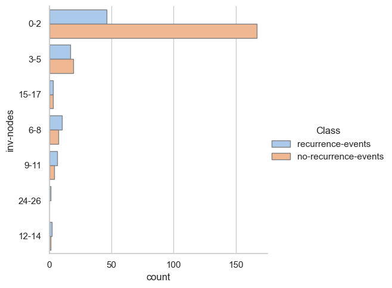

```python
sns.catplot(y = "inv-nodes",
            hue = "Class",
            kind = "count",
            palette = "pastel",
            edgecolor = ".5",
            data = df)
```

## Aside: Anscombe Quartet

```python
# source: https://matplotlib.org/stable/gallery/specialty_plots/anscombe.html
import matplotlib.pyplot as plt
import numpy as np

x = [10, 8, 13, 9, 11, 14, 6, 4, 12, 7, 5]
y1 = [8.04, 6.95, 7.58, 8.81, 8.33, 9.96, 7.24, 4.26, 10.84, 4.82, 5.68]
y2 = [9.14, 8.14, 8.74, 8.77, 9.26, 8.10, 6.13, 3.10, 9.13, 7.26, 4.74]
y3 = [7.46, 6.77, 12.74, 7.11, 7.81, 8.84, 6.08, 5.39, 8.15, 6.42, 5.73]
x4 = [8, 8, 8, 8, 8, 8, 8, 19, 8, 8, 8]
y4 = [6.58, 5.76, 7.71, 8.84, 8.47, 7.04, 5.25, 12.50, 5.56, 7.91, 6.89]

datasets = {
    'I': (x, y1),
    'II': (x, y2),
    'III': (x, y3),
    'IV': (x4, y4)
}
```

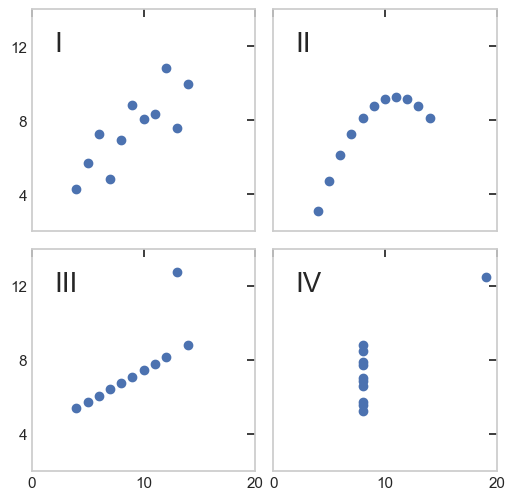

```python
fig, axs = plt.subplots(2, 2,
                        sharex = True,
                        sharey = True,
                        figsize = (6, 6),
                        gridspec_kw = {'wspace': 0.08, 'hspace': 0.08})
axs[0, 0].set(xlim = (0, 20), ylim = (2, 14))
axs[0, 0].set(xticks = (0, 10, 20), yticks = (4, 8, 12))

for ax, (label, (x, y)) in zip(axs.flat, datasets.items()):
    ax.grid()
    ax.text(0.1, 0.9, label, fontsize = 20, transform = ax.transAxes, va = 'top')
    ax.tick_params(direction = 'in', top = True, right = True)
    ax.plot(x, y, 'o')

plt.show()
```

What’s special in these scatter plots?

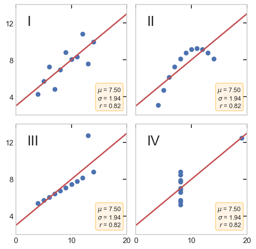

```python
fig, axs = plt.subplots(2, 2,
                        sharex = True,
                        sharey = True,
                        figsize = (6, 6),
                        gridspec_kw = {'wspace': 0.08, 'hspace': 0.08})
axs[0, 0].set(xlim = (0, 20), ylim = (2, 14))
axs[0, 0].set(xticks = (0, 10, 20), yticks = (4, 8, 12))

for ax, (label, (x, y)) in zip(axs.flat, datasets.items()):
    ax.grid()
    ax.text(0.1, 0.9, label, fontsize = 20, transform = ax.transAxes, va = 'top')
    ax.tick_params(direction = 'in', top = True, right = True)
    ax.plot(x, y, 'o')

###################### NEW PART ######################
    # linear regression
    p1, p0 = np.polyfit(x, y, deg = 1)  # slope, intercept
    ax.axline(xy1 = (0, p0), slope = p1, color = 'r', lw = 2)

    # add text box for the statistics
    stats = (f'$\\mu$ = {np.mean(y):.2f}\n'
             f'$\\sigma$ = {np.std(y):.2f}\n'
             f'$r$ = {np.corrcoef(x, y)[0][1]:.2f}')
    bbox = dict(boxstyle = 'round', fc = 'blanchedalmond', ec = 'orange', alpha = 0.5)
    ax.text(0.95, 0.07, stats, fontsize = 9, bbox = bbox,
            transform = ax.transAxes, horizontalalignment = 'right')
###################### NEW PART ######################

plt.show()
```

What’s special in these scatter plots?

- four data sets, each with eleven points
- nearly identical simple descriptive statistics
- very different when graphed

**Lessons learned:**

- importance of graphing data
- effect of outliers on statistical properties
- statistic properties are important but may be not sufficient